# Practical ML

## Bulding our Prediction Model

We are going to build random forest model and check it’s accuracy on the cleaned data which we have made and then we use train function along with new cleaned data for three-crossed validation.

#### Random Forest Model

```r
#Random Forest Model creation
random_forest_model <- randomForest(as.factor(classe) ~ ., data=sub_training2, method="class")
prediction_random_forest <- predict(random_forest_model, sub_testing2, type = "class")
```

```r
#We are using this confusion_matrix to check its accuracy
cmrf<-confusionMatrix(prediction_random_forest, factor(sub_testing2$classe))
```

We get a very high accuracy of 0.99473237. With this we will plot it on a graph

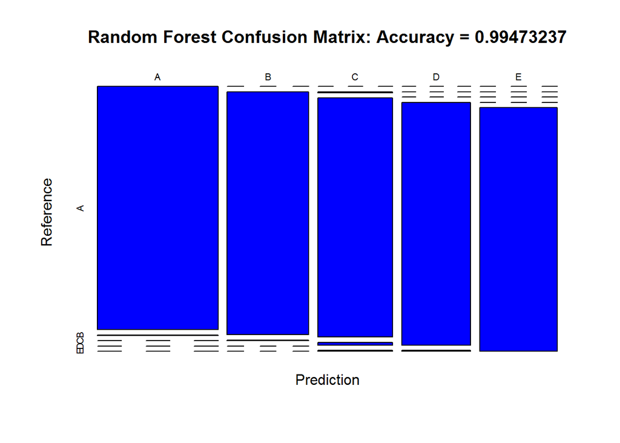

```r
#Plotting the accuracy of Random Forest model on graph

plot(cmrf$table,col="blue", main = paste("Random Forest Confusion Matrix: Accuracy =", round(cmrf$overall['Accuracy'], 8)))
```

Hence due to it’s high accuracy we could say that Random Forest model can be used.

#### Prediction on a rebuild model

Now we are going to train our model again so we don’t predict on a reduced set of data

```r
#Again removing variable with zero variance but on raw data
Train_again <- nearZeroVar(var_train)
testing_again <- var_valid[, -Train_again]
training_again <- var_train[, -Train_again]
```

We need to again remove NA values as it will cause error in the process

```r
#Removing NA values
not_applicable <- sapply(training_again, function(z) mean(is.na(z))) > 0.95
```

```r
#Removing NA values
training_again_2 <- training_again[, not_applicable==F]
testing_again_2 <- testing_again[, not_applicable==F]
```

This time we will remove the first 5 variables which basically are varaibles which can’t be used in our data like time-stamp etc.

```r
#removing un-used data
training_again_3 <- training_again_2[, -(1:5)]
testing_again_3 <- testing_again_2[, -(1:5)]
```

We will use the train function in rf mode to train our data

```r
#Training of data
variable_control <- trainControl(method="cv", number=3, verboseIter=F)
fitness_model <- train(classe ~ ., data=training_again_3, method="rf", trControl=variable_control)
final_model <- predict(fitness_model, newdata=testing_again_3)
```

Finally we predict the analysis on new test set

```r
#testing and converting to character
final_model <- predict(fitness_model, newdata=testing_again_3)
final_model<- as.character(final_model)
```

## Conclusion

#### Sumbission

```r
#Using the Random Forest Algorithm we generate files for submission.
variable_write_PML <- function(z) {
  len <- length(z)
  for(k in 1:len) {
    file_name_var = paste0("problem_id_", k, ".txt")
    write.table(z[k], file=file_name_var, quote=F, row.names=F, col.names=F)
  }
}
```

```r
#Final submission
variable_write_PML(final_model)
```